# Gamma Distribution

Sofia Hirschmann

21 December 2021

```r
library(mosaic)
library(tidyverse)
library(patchwork)
library(dplyr)
library(ggplot2)
```

# Description

The gamma distribution can be understood through comparison to the exponential distribution, which is a special case of the gamma distribution. The exponential distribution predicts the wait time until the *very first* event. On the other hand, the gamma distribution predicts the wait time until the *n-th* event takes place.

While the notation of the exponential distribution is written as Exponential (β) because alpha is assumed to be one for the *first* event, the gamma distribution is writen as Gamma (α,β/λ).

**α**

- α or alpha is the parameter for the number of events you are waiting for

**β/λ**

- β or beta is the scale parameter for the mean waiting time between events (β = 1 / λ)
- λ or lambda is the rate at which the events are happening (λ = 1 / β)

The two gamma parameters are both always positive, because one is the number of events and the other is the rate of events, neither of which make sense being negative.

Examples of scenarios that can be solved using a gamma distribution are wait time modeling, reliability or failure modeling, service time modeling, etc.

# Use and Equations

The **expected value** of a gamma distibution is calcultaed by multiplying alpha and beta
$$μ=E(Y)=αβ$$

The **variance** of a gamma distribution is calculated by multiplying alpha and beta squared
$$σ^2=Var(Y)=αβ^2$$

To determine whether a variable Y has a gamma distribution…It must be determined that:

$$f(y)= \frac {1}{βαΓ(α)}y^{α−1} e^{ −y/β}$$
…Where:
$$Γ(α)=\int_0^∞y^{α−1}e^{−y}dy$$

The gamma function **Γ(α)** can be found through these observations:

- Γ(1)=1
- Γ(n)=(n−1)!
- Γ(α)=(α−1)Γ(α−1) for any α>1

The **probability function** of a gamma distribution is found through the integral of f(y)

$$P(a≤Y≤b)=\int_a^bf(y)dy$$

# Properties

**The skewness of the gamma distribution depends on its parameters, as seen through the following visuals of variation in shape and scale parameters.**

**Example:** For the context of these visualizations we will use the real world example of emergency room wait times explored through different measures of alpha and beta parameters. (Using *dgamma* returns the corresponding gamma probability density values for a vector of quantiles)

### Varying Shape

**Calculating the gamma probability density for the patient number seen at each moment in time when the scale is two, aka the mean waiting time between patients being seen is 2 hours.**

- The following model evaluates the probabilities for the elapsed time of a varying number of patients being seen, with a scale parameter equal to 2. The skewness of the gamma distribution depends on its shape parameter as seen through these observations that follow a right skewed negative binomial distribution, as the shape parameter increases the distribution becomes less skewed. The scale of 2 is clearly shown through the varying alpha variables since the peak probability of the fourth patient being seen is within the range of 5 and 8 (when the calculated E(Y) would be 8), and the peak proability of the seventh patient being seen is within the range of 10 and 16 (when the calculated E(Y) would be 14).

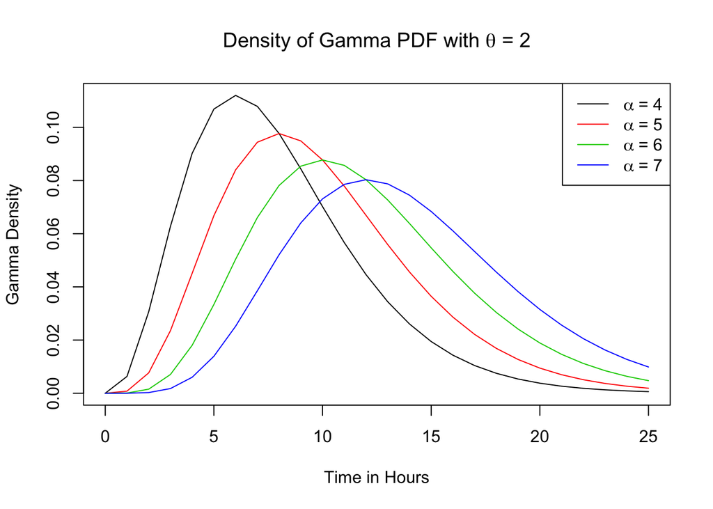

```r
x <- seq(0, 25, by = 1)

shape_param <- 4:7

plot(x, dgamma(x, shape = shape_param[1], scale = 2), type = "l", ylab = "Gamma Density", xlab = "Time in Hours")

for (k in 2:length(shape_param)) {
  lines(x, dgamma(x, shape = shape_param[k], scale = 2), col = k)
}

title(substitute(paste("Density of Gamma PDF with ", theta, " = 2")))

legend("topright", c(expression(alpha ~ '= 4'), expression(alpha ~ '= 5'),
                     expression(alpha ~ '= 6'), expression(alpha ~ '= 7')),
       lty = 1, col = 1:4)
```

### Varying Scale

**Calcultaing the gamma probability density of the patient being seen at each moment in time is the fourth patient given a variety of mean time between the moments patients are seen (2 through 5 every hour)**

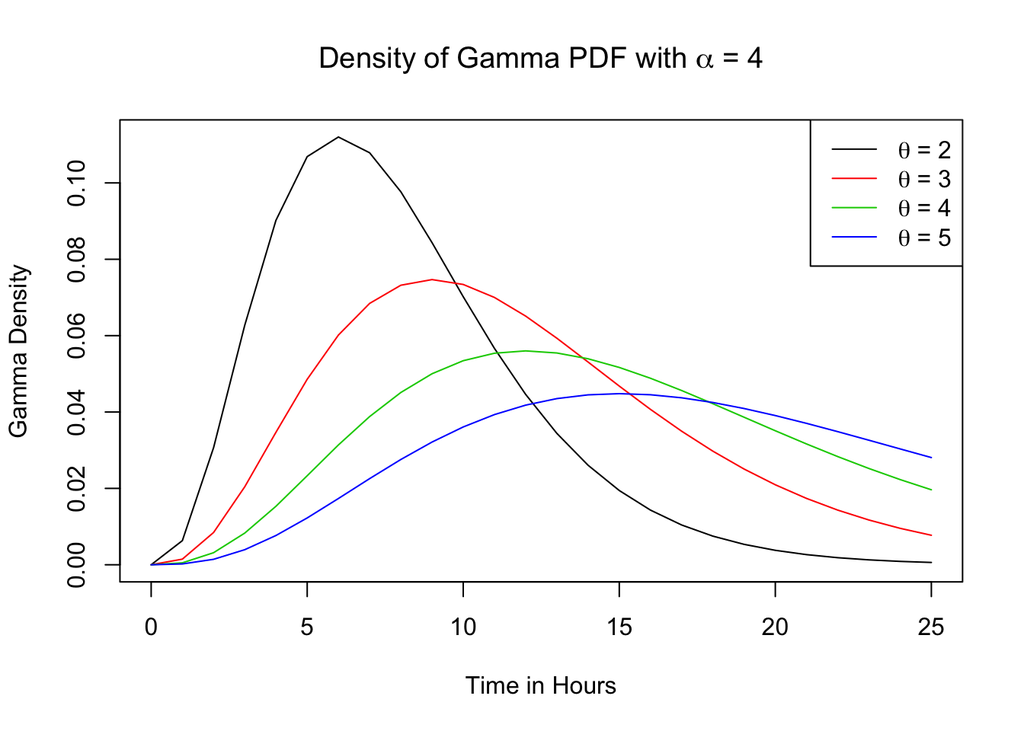

```r
x <- seq(0, 25, by = 1)

scale_param <- seq(2,5, by = 1)

plot(x, dgamma(x, shape = 4, scale = scale_param[1]), type = "l", ylab = "Gamma Density",  xlab = "Time in Hours")

for (i in 2:length(scale_param)) {
  lines(x, dgamma(x, shape = 4, scale = scale_param[i]), col = i)
}

legend("topright", c(expression(theta ~ '= 2'), expression(theta ~ '= 3'),
                     expression(theta ~'= 4'), expression(theta ~ '= 5')),
       lty = 1, col = 1:4)
title(substitute(paste("Density of Gamma PDF with"," ", alpha, " = 4")))
```

# Relation to Exp/Chi

**The gamma distribution is directly connected to the the exponential distribution and the chi squared distribution**

- A gamma distribution with shape parameter α = v/2 and rate parameter β = 1/2 is a chi-squared distribution with ν degrees of freedom.
- A gamma distribution with shape parameter α = 1 and rate parameter β is an exponential distribution with rate parameter β. The sum of n exponential(β) random variables is a gamma(n, β) random variable.
- A chi-squared distribution with 2 degrees of freedom (k = 2) is an exponential distribution with a mean value of 2 (rate λ = 1/2).

### Comparison Gamma to Exp

The exponential distribution and the gamma distribution are the same with the difference that the gamma finds the probability of a determined number of events occuring over an elapsed period of time as opposed to finding the first event occuring over an elapsed period of time through an exponential distribution. The concept that they are the same distribution can be shown through using the method of moment-generating functions. Generating though simulation a sample of n exponential(beta) values, calculating the sum of these values, and modeling that simulation sum repeated a number of times results in a distribution that strongly correlates wuth the resulting model from simulating gamma(n, beta).

**As seen below with the histogram of rgamma(n = 1000, shape = 5, rate = 1/2) compared to the histogram of the replicated sum of rexp(n = 5, rate = 1/2), it is clear that the two follow a very similar distribution.**

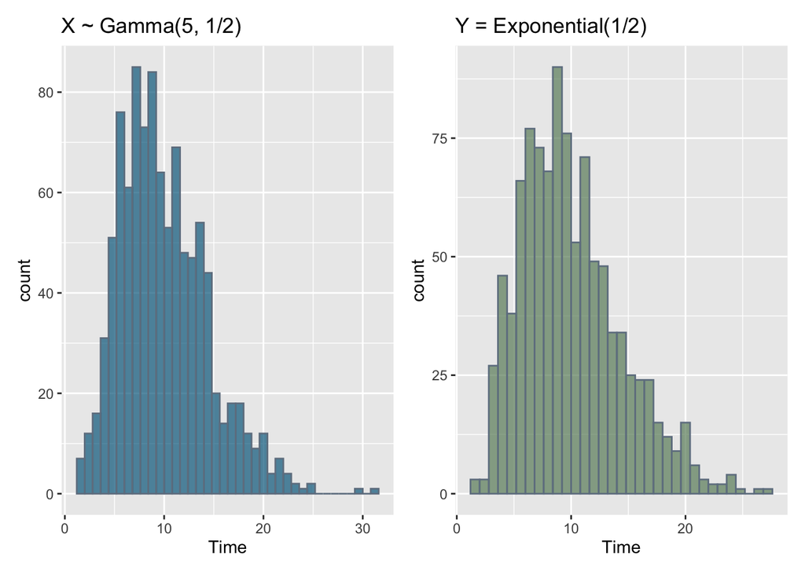

```r
set.seed(338)

X = rgamma(n = 1000, shape = 5, rate = 1/2)
plot_x = gf_histogram( ~ X, fill = "deepskyblue4", color = "slategrey", binwidth = .8, alpha = .7, xlab = 'Time') +
  labs(title = "X ~ Gamma(5, 1/2)")

Y_sum = replicate(n = 1000, {
    Y = rexp(n = 5, rate = 1/2)
    sum(Y)
})

plot_y = gf_histogram( ~ Y_sum, fill = "darkseagreen4", color = "slategrey", binwidth = .8, alpha = .7, xlab = 'Time') +
  labs(title = "Y = Exponential(1/2)")

plot_x + plot_y
```

### Comparing Gamma to Chi

Similarly there is great resemblance between the gamma distributions and the chi squared distribution, since they are also technically the same distribution.

- In order for the chi squared distribution to match the gamma distribution, degrees of freedome or v = 2 is required because v/2 is equal to α = 1

**The comparison of a simulation of random gamma samples to the distribution of probability densities for the chi squared distributions show, similarly to the above visuals, that the the two follow nearly the same distribution.**

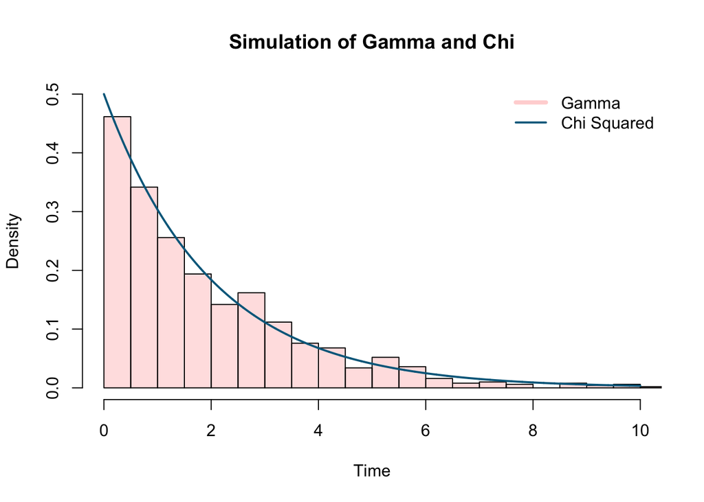

```r
set.seed(338)

g = rgamma(n = 0 : 1000 / 100, shape = 1, scale = 2)

hist(g,
     breaks = 'Scott',
     freq = FALSE,
     xlim = c(0,10),
     ylim = c(0,0.5),
     xlab = 'Time',
     main="Simulation of Gamma and Chi",
     col=rgb(1,0,0,1/7))

curve(dchisq(x, df = 2), from = 0, to = 10, n = 5000, col= 'deepskyblue4', lwd=2, add = T)

legend("topright", c("Gamma", "Chi Squared"), box.lty = 0,
        lty = 1, col = c(rgb(1,0,0,1/5), "deepskyblue4"), lwd = c(4, 2, 2))
```

[output not shown]